# Practical Machine Learning - Course Project

Shrishti Kaushik

17/04/2020

## Project Brief

### Background

Using devices such as Jawbone Up, Nike FuelBand, and Fitbit it is now possible to collect a large amount of data about personal activity relatively inexpensively. These type of devices are part of the quantified self movement – a group of enthusiasts who take measurements about themselves regularly to improve their health, to find patterns in their behavior, or because they are tech geeks. One thing that people regularly do is quantify how much of a particular activity they do, but they rarely quantify how well they do it. In this project, your goal will be to use data from accelerometers on the belt, forearm, arm, and dumbell of 6 participants. They were asked to perform barbell lifts correctly and incorrectly in 5 different ways. More information is available from the website here: http://web.archive.org/web/20161224072740/http:/groupware.les.inf.puc-rio.br/har (see the section on the Weight Lifting Exercise Dataset).

### Data

The training data for this project are available here: https://d396qusza40orc.cloudfront.net/predmachlearn/pml-training.csv The test data are available here: https://d396qusza40orc.cloudfront.net/predmachlearn/pml-testing.csv

### Goal

The goal of your project is to predict the manner in which they did the exercise. This is the “classe” variable in the training set.

## Data Pre-processing

First let’s load the data and then look at the dimensions of the training data and it’s summary.

```r
pmltest<-read.csv("C:\\Users\\Shrishti\\Downloads\\pml-testing.csv")
pmltrain<-read.csv("C:\\Users\\Shrishti\\Downloads\\pml-training.csv")
str(pmltrain)
```

```
## 'data.frame':    19622 obs. of  160 variables:
##  $ X                       : int  1 2 3 4 5 6 7 8 9 10 ...
##  $ user_name               : Factor w/ 6 levels "adelmo","carlitos",..: 2 2 2 2 2 2 2 2 2 2 ...
##  $ raw_timestamp_part_1    : int  1323084231 1323084231 1323084231 1323084232 1323084232 1323084232 1323084232 1323084232 1323084232 1323084232 ...
##  $ raw_timestamp_part_2    : int  788290 808298 820366 120339 196328 304277 368296 440390 484323 484434 ...
##  $ cvtd_timestamp          : Factor w/ 20 levels "02/12/2011 13:32",..: 9 9 9 9 9 9 9 9 9 9 ...
##  $ new_window              : Factor w/ 2 levels "no","yes": 1 1 1 1 1 1 1 1 1 1 ...
##  $ num_window              : int  11 11 11 12 12 12 12 12 12 12 ...
##  $ roll_belt               : num  1.41 1.41 1.42 1.48 1.48 1.45 1.42 1.42 1.43 1.45 ...
##  $ pitch_belt              : num  8.07 8.07 8.07 8.05 8.07 8.06 8.09 8.13 8.16 8.17 ...
##  $ yaw_belt                : num  -94.4 -94.4 -94.4 -94.4 -94.4 -94.4 -94.4 -94.4 -94.4 -94.4 ...
##  $ total_accel_belt        : int  3 3 3 3 3 3 3 3 3 3 ...
##  $ kurtosis_roll_belt      : Factor w/ 397 levels "","-0.016850",..: 1 1 1 1 1 1 1 1 1 1 ...
##  $ kurtosis_picth_belt     : Factor w/ 317 levels "","-0.021887",..: 1 1 1 1 1 1 1 1 1 1 ...
##  $ kurtosis_yaw_belt       : Factor w/ 2 levels "","#DIV/0!": 1 1 1 1 1 1 1 1 1 1 ...
```

[output cut: 86 more lines]

So the training data has 19,622 observations and 160 variables. Also, the first seven variables can be considered irrelevant for predicting our target variable as they only contain information about the user. Therefore we can remove the first seven coloumns from our datset. Let’s check for any rows or columns with “NA” values and remove them too.

```r
sum(colSums(is.na(pmltrain) | pmltrain=="")!=0)
```

```
## [1] 100
```

```r
pmltrain_c<-pmltrain[,colSums(is.na(pmltrain) | pmltrain=="")==0]
pmltrain_c<-pmltrain_c[,-c(1:7)]
```

Now let’s look at the dimensions of our training data.

```r
dim(pmltrain_c)
```

```
## [1] 19622    53
```

Now let’s divide our trainig data into a validation dataset and training dataset.

```r
pmlvalid<-createDataPartition(pmltrain_c$classe,p=0.8,list=FALSE)
pmlvalid_c<-pmltrain_c[-pmlvalid,]
pmltrain_c<-pmltrain_c[pmlvalid,]
```

Now that we have cleaned our data and partitioned it, let’s do some data analysis.

## Data Analysis

To analyse our data we will first make a table of the “classe” variable and the we will calculate the correlation between our target variable and other variables. We will also try to see if any strong correlations exist between any of the predictor variables using corrplot package in R.

```r
table(pmltrain_c$classe)
```

```
##
##    A    B    C    D    E
## 4464 3038 2738 2573 2886
```

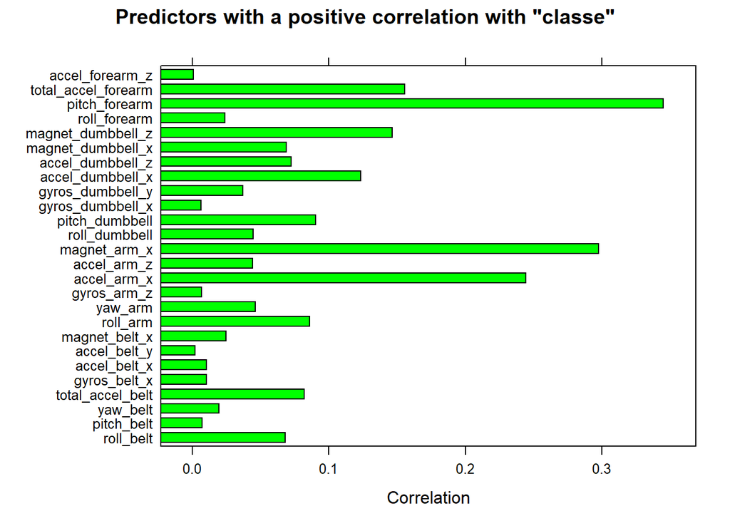

```r
a<-apply(pmltrain_c[,c(1:52)],2,function(x) cor(x,as.numeric(pmltrain_c$classe)))
barchart(a[a>0],xlab = "Correlation",col="green",main="Predictors with a positive correlation with \"classe\"")
```

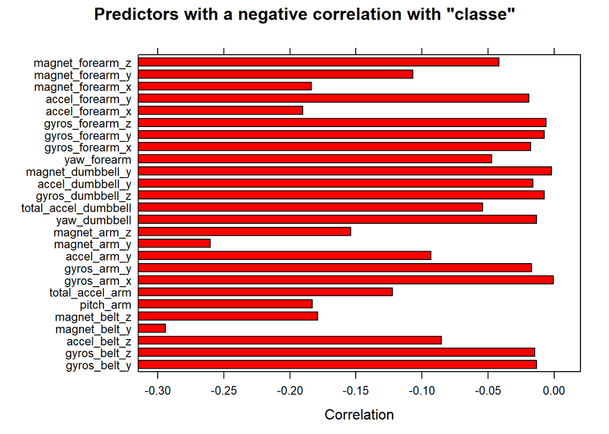

```r
barchart(a[a<0],xlab = "Correlation",main="Predictors with a negative correlation with \"classe\"",col="red")
```

From the plots of correlation of the predictors with the variable “classe”, we can see that the maximum positive correlation exists with “pitch_forearm” and maximum negative correlation exists with “magnet_bell_Y”. Let’s look at the exact values of their correlation with “classe”.

```r
corcoef=c(a[which.max(a)],a[which.min(a)])
corcoef
```

```
## pitch_forearm magnet_belt_y
##     0.3446622    -0.2943227
```

It can be observed that both the variables are only slightly correlated to the variable “classe”. Now let’s look for any closely correlated predictors in our dataset.

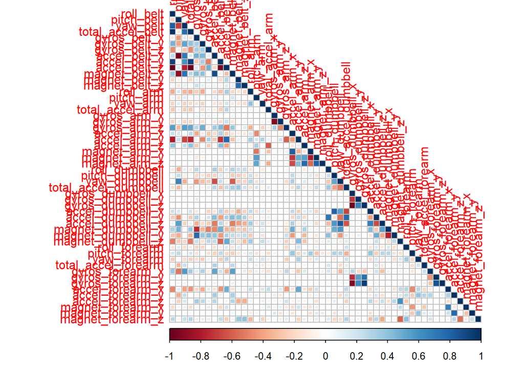

```r
c<-cor(pmltrain_c[,c(1:52)])
corrplot(c,method = "square",type = "lower")
```

From the correlation plot it can be observed that very few variables are strongly correlated with one another. Let’s look at these variables. The “findCorrelation” function of “caret” package in R returns a vector of integers corresponding to columns to remove to reduce pair-wise correlations.

```r
hc<-findCorrelation(c,cutoff = 0.8,names=TRUE)
hc
```

```
##  [1] "accel_belt_z"     "roll_belt"        "accel_belt_y"     "accel_dumbbell_z"
##  [5] "accel_belt_x"     "pitch_belt"       "accel_arm_x"      "accel_dumbbell_x"
##  [9] "magnet_arm_y"     "gyros_forearm_y"  "gyros_dumbbell_x" "gyros_dumbbell_z"
## [13] "gyros_arm_x"
```

Now let’s look these variables correlation with our target variable and observe if any of these variables are highly correlated with the “classe” variable.

```r
a[hc]
```

```
##     accel_belt_z        roll_belt     accel_belt_y accel_dumbbell_z
##    -0.0853148053     0.0681118995     0.0023556895     0.0726384094
##     accel_belt_x       pitch_belt      accel_arm_x accel_dumbbell_x
##     0.0105750321     0.0071893007     0.2442122215     0.1234388364
##     magnet_arm_y  gyros_forearm_y gyros_dumbbell_x gyros_dumbbell_z
##    -0.2602737247    -0.0073204985     0.0064993653    -0.0073151995
##      gyros_arm_x
##    -0.0004216744
```

None of the variables seem to be highly correlated with our target variable. But since the models that we will be using to predict the user’s activity are random forest and other non-linear algorithms, they won’t be highly with the presence of these variables.

## Model Building

```r
trc<-trainControl(method = "cv",number = 10)
```

### 1) Linear Discriminant Analysis (lda)

First let’s build the model and look at its accuracy.

```r
ldamod<-train(classe~.,data = pmltrain_c,method="lda",metric="Accuracy",trControl=trc)
print(ldamod)
```

```
## Linear Discriminant Analysis
##
## 15699 samples
##    52 predictor
##     5 classes: 'A', 'B', 'C', 'D', 'E'
##
## No pre-processing
## Resampling: Cross-Validated (10 fold)
## Summary of sample sizes: 14128, 14130, 14130, 14129, 14129, 14130, ...
## Resampling results:
##
##   Accuracy   Kappa
##   0.7037384  0.6252097
```

Now let’s predict and check the confusion matrix.

```r
plda<-predict(ldamod,pmlvalid_c)
confusionMatrix(plda,pmlvalid_c$classe)
```

```
## Confusion Matrix and Statistics
##
##           Reference
## Prediction   A   B   C   D   E
##          A 902 116  75  46  18
##          B  26 487  59  25 121
##          C 100  89 459  68  81
##          D  86  29  74 477  99
##          E   2  38  17  27 402
##
## Overall Statistics
##
##                Accuracy : 0.6951
##                  95% CI : (0.6805, 0.7095)
##     No Information Rate : 0.2845
##     P-Value [Acc > NIR] : < 2.2e-16
##
##                   Kappa : 0.6144
##
##  Mcnemar's Test P-Value : < 2.2e-16
##
## Statistics by Class:
##
##                      Class: A Class: B Class: C Class: D Class: E
## Sensitivity            0.8082   0.6416   0.6711   0.7418   0.5576
## Specificity            0.9092   0.9270   0.8956   0.9122   0.9738
## Pos Pred Value         0.7796   0.6783   0.5759   0.6235   0.8272
## Neg Pred Value         0.9226   0.9151   0.9280   0.9474   0.9072
## Prevalence             0.2845   0.1935   0.1744   0.1639   0.1838
## Detection Rate         0.2299   0.1241   0.1170   0.1216   0.1025
## Detection Prevalence   0.2949   0.1830   0.2032   0.1950   0.1239
## Balanced Accuracy      0.8587   0.7843   0.7833   0.8270   0.7657
```

This algorithm has an accuray of around 70% and high Specificity values for all classes. This means that this model is highly accurate when it comes to correctly identifying a class that the user doesn’t belong to. But the sensitivity values are relatively lower. Hence it not as accurate when it comes to correctly identifying a class that the user belongs to.

### 2) Decision Tree

Building the model:

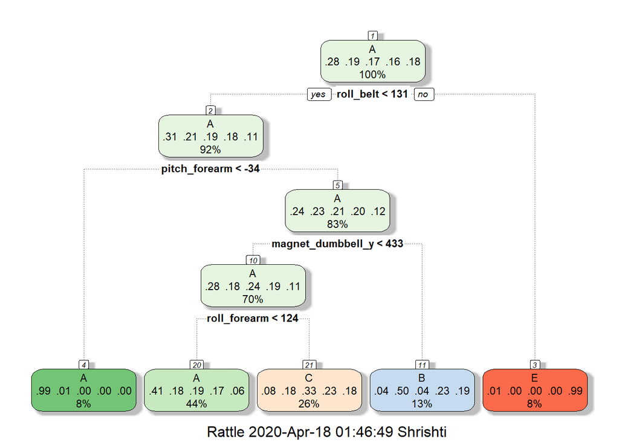

```r
treemod<-train(classe~.,data = pmltrain_c,method="rpart",metric="Accuracy",trControl=trc)
fancyRpartPlot(treemod$finalModel)
```

Predicting the values and building the confusion matrix:

```r
ptree<-predict(treemod,pmlvalid_c)
confusionMatrix(ptree,pmlvalid_c$classe)
```

```
## Confusion Matrix and Statistics
##
##           Reference
## Prediction    A    B    C    D    E
##          A 1013  302  313  284  106
##          B   25  269   21  117   96
##          C   73  188  350  242  205
##          D    0    0    0    0    0
##          E    5    0    0    0  314
##
## Overall Statistics
##
##                Accuracy : 0.496
##                  95% CI : (0.4803, 0.5118)
##     No Information Rate : 0.2845
##     P-Value [Acc > NIR] : < 2.2e-16
##
##                   Kappa : 0.3418
##
##  Mcnemar's Test P-Value : NA
##
## Statistics by Class:
##
##                      Class: A Class: B Class: C Class: D Class: E
## Sensitivity            0.9077  0.35441  0.51170   0.0000  0.43551
## Specificity            0.6420  0.91814  0.78141   1.0000  0.99844
## Pos Pred Value         0.5020  0.50947  0.33081      NaN  0.98433
## Neg Pred Value         0.9459  0.85567  0.88342   0.8361  0.88707
## Prevalence             0.2845  0.19347  0.17436   0.1639  0.18379
## Detection Rate         0.2582  0.06857  0.08922   0.0000  0.08004
## Detection Prevalence   0.5144  0.13459  0.26969   0.0000  0.08132
## Balanced Accuracy      0.7748  0.63628  0.64655   0.5000  0.71697
```

This model is highly inaccurate. It’s accuracy for predicting class “D” is exceptionally bad as it can be observed from both the plot of the decision tree and the confusion matrix. This model has an accuracy of around 49% only.

### 3) Knn Algorithm

Building the model:

```r
knnmod<-train(classe~.,data = pmltrain_c,method="knn",metric="Accuracy",trControl=trc)
print(knnmod)
```

```
## k-Nearest Neighbors
##
## 15699 samples
##    52 predictor
##     5 classes: 'A', 'B', 'C', 'D', 'E'
##
## No pre-processing
## Resampling: Cross-Validated (10 fold)
## Summary of sample sizes: 14129, 14131, 14128, 14130, 14130, 14129, ...
## Resampling results across tuning parameters:
##
##   k  Accuracy   Kappa
##   5  0.9148991  0.8923329
##   7  0.8927317  0.8642292
##   9  0.8761065  0.8431471
##
## Accuracy was used to select the optimal model using the largest value.
## The final value used for the model was k = 5.
```

Predicting and building the confusion matrix:

```r
pknn<-predict(knnmod,pmlvalid_c)
confusionMatrix(pknn,pmlvalid_c$classe)
```

```
## Confusion Matrix and Statistics
##
##           Reference
## Prediction    A    B    C    D    E
##          A 1082   41   12    4    9
##          B    6  657   18    3   12
##          C   14   29  631   40   12
##          D   13   17   16  590   25
##          E    1   15    7    6  663
##
## Overall Statistics
##
##                Accuracy : 0.9235
##                  95% CI : (0.9148, 0.9317)
##     No Information Rate : 0.2845
##     P-Value [Acc > NIR] : < 2.2e-16
##
##                   Kappa : 0.9032
##
##  Mcnemar's Test P-Value : 1.002e-11
##
## Statistics by Class:
##
##                      Class: A Class: B Class: C Class: D Class: E
## Sensitivity            0.9695   0.8656   0.9225   0.9176   0.9196
## Specificity            0.9765   0.9877   0.9707   0.9784   0.9909
## Pos Pred Value         0.9425   0.9440   0.8691   0.8926   0.9581
## Neg Pred Value         0.9877   0.9684   0.9834   0.9838   0.9820
## Prevalence             0.2845   0.1935   0.1744   0.1639   0.1838
## Detection Rate         0.2758   0.1675   0.1608   0.1504   0.1690
## Detection Prevalence   0.2926   0.1774   0.1851   0.1685   0.1764
## Balanced Accuracy      0.9730   0.9266   0.9466   0.9480   0.9552
```

This model is far better than the previous models as it has an accuracy of around 92%. Also the confusion matrix looks much better for this model as compared to the models above. All the classes have high values for specificity as well as sensitivity.

### 4) Random Forest

Building the model:

```r
trcrf<-trainControl(method = "cv",number = 3)
rfmod<-train(classe~.,data = pmltrain_c,method="rf",metric="Accuracy",trControl=trcrf)
print(rfmod)
```

```
## Random Forest
##
## 15699 samples
##    52 predictor
##     5 classes: 'A', 'B', 'C', 'D', 'E'
##
## No pre-processing
## Resampling: Cross-Validated (3 fold)
## Summary of sample sizes: 10465, 10466, 10467
## Resampling results across tuning parameters:
##
##   mtry  Accuracy   Kappa
##    2    0.9910184  0.9886386
##   27    0.9914005  0.9891223
##   52    0.9847124  0.9806602
##
## Accuracy was used to select the optimal model using the largest value.
## The final value used for the model was mtry = 27.
```

Predicting and building the confusion matrix:

```r
prf<-predict(rfmod,pmlvalid_c)
confusionMatrix(prf,pmlvalid_c$classe)
```

```
## Confusion Matrix and Statistics
##
##           Reference
## Prediction    A    B    C    D    E
##          A 1115    6    0    0    0
##          B    0  751    1    0    0
##          C    1    2  680    9    0
##          D    0    0    3  632    4
##          E    0    0    0    2  717
##
## Overall Statistics
##
##                Accuracy : 0.9929
##                  95% CI : (0.9897, 0.9953)
##     No Information Rate : 0.2845
##     P-Value [Acc > NIR] : < 2.2e-16
##
##                   Kappa : 0.991
##
##  Mcnemar's Test P-Value : NA
##
## Statistics by Class:
##
##                      Class: A Class: B Class: C Class: D Class: E
## Sensitivity            0.9991   0.9895   0.9942   0.9829   0.9945
## Specificity            0.9979   0.9997   0.9963   0.9979   0.9994
## Pos Pred Value         0.9946   0.9987   0.9827   0.9890   0.9972
## Neg Pred Value         0.9996   0.9975   0.9988   0.9967   0.9988
## Prevalence             0.2845   0.1935   0.1744   0.1639   0.1838
## Detection Rate         0.2842   0.1914   0.1733   0.1611   0.1828
## Detection Prevalence   0.2858   0.1917   0.1764   0.1629   0.1833
## Balanced Accuracy      0.9985   0.9946   0.9952   0.9904   0.9969
```

It can be clearly observed that this model has the best accuracy although the model building takes a considerable amount of time as compared to the other models. It has an accuracy of 99% and its confusion matrix shows that it predicts every class almost fully correctly.

## Conclusion

Finally we can conclude that the random forest model is the best to predict the “classe” variable. So lets run our model on our test data:

```r
finalp<-predict(rfmod,pmltest)
finalp
```

```
##  [1] B A B A A E D B A A B C B A E E A B B B
## Levels: A B C D E
```